# QM640 Data Analytics Capstone - Final Analysis Evidence Notebook

**Project:** Evaluating the Business Impact of Artificial Intelligence Adoption Across the Quality Engineering Lifecycle  
**Student:** Satish Venugopal  
**Walsh College - QM640 Data Analytics Capstone**  
**Mentor:** Dr. Sanhita Karmakar  
**Final submission:** 13-August-2026

This executed notebook provides a compact verification of the final analytical evidence. The complete regeneration workflow, including repeated model validation, is contained in `../scripts/final_analysis.py`; generated result tables are retained under `../outputs/tables/`.

```python
from pathlib import Path
import math, sys
import numpy as np
import pandas as pd
from scipy import stats
from IPython.display import display, Image, Markdown

ROOT = Path.cwd().parent if Path.cwd().name == "notebooks" else Path.cwd()
TABLES = ROOT / "outputs" / "tables"
FIGURES = ROOT / "outputs" / "figures"
PROJECT = pd.read_csv(ROOT / "data" / "processed" / "EQEPD_Cleaned_Project_Level.csv")
PHASE = pd.read_csv(ROOT / "data" / "processed" / "EQEPD_Engineered_Phase_Level.csv")
VALID = PHASE.dropna(subset=["Baseline_Effort", "Actual_Effort", "Productivity_Improvement_Pct"]).copy()
print("Repository root:", ROOT)
print("Python:", sys.version.split()[0])
print("Clean project/sprint observations:", len(PROJECT))
print("Valid phase observations:", len(VALID))
```

```
Repository root: /mnt/data/QM640_work/QM640
Python: 3.13.5
Clean project/sprint observations: 457
Valid phase observations: 2705
```

## 1. Dataset and Target Verification

The final study uses the same cleaned and engineered datasets developed during the interim milestone and adds robustness, validation, and implementation evidence. The phase outcome is `Productivity_Improvement_Pct = (Baseline_Effort - Actual_Effort) / Baseline_Effort * 100`.

```python
inventory = pd.DataFrame({
    "Measure": ["Raw records", "Clean project/sprint records", "Potential phase records", "Valid phase records", "AI-assisted valid phase records", "Traditional valid phase records"],
    "Value": [459, len(PROJECT), len(PROJECT)*6, len(VALID), int((VALID.AI_Used=="Yes").sum()), int((VALID.AI_Used=="No").sum())]
})
display(inventory)
```

|  | Measure | Value |
| --- | --- | --- |
| 0 | Raw records | 459 |
| 1 | Clean project/sprint records | 457 |
| 2 | Potential phase records | 2742 |
| 3 | Valid phase records | 2705 |
| 4 | AI-assisted valid phase records | 906 |
| 5 | Traditional valid phase records | 1799 |

## 2. RQ1 - AI-Assisted Versus Traditional Productivity

The primary comparison uses Mann-Whitney U because the productivity distribution includes outliers and unequal variance. Welch's t-test and effect sizes provide sensitivity evidence.

```python
ai = VALID.loc[VALID.AI_Used=="Yes", "Productivity_Improvement_Pct"].dropna().to_numpy()
traditional = VALID.loc[VALID.AI_Used=="No", "Productivity_Improvement_Pct"].dropna().to_numpy()
mw = stats.mannwhitneyu(ai, traditional, alternative="two-sided")
welch = stats.ttest_ind(ai, traditional, equal_var=False)
pooled = math.sqrt(((len(ai)-1)*np.var(ai,ddof=1)+(len(traditional)-1)*np.var(traditional,ddof=1))/(len(ai)+len(traditional)-2))
d = (ai.mean()-traditional.mean())/pooled
rb = 2*mw.statistic/(len(ai)*len(traditional))-1
rq1 = pd.DataFrame([{
    "AI N":len(ai), "Traditional N":len(traditional), "AI Mean %":ai.mean(), "Traditional Mean %":traditional.mean(),
    "Difference points":ai.mean()-traditional.mean(), "Mann-Whitney U":mw.statistic, "MW p":mw.pvalue,
    "Welch t":welch.statistic, "Welch p":welch.pvalue, "Cohen d":d, "Rank-biserial":rb
}])
display(rq1.round(4))
display(pd.read_csv(TABLES / "Final_RQ1_Sensitivity_Analysis.csv").round(4))
```

|  | AI N | Traditional N | AI Mean % | Traditional Mean % | Difference points | Mann-Whitney U | MW p | Welch t | Welch p | Cohen d | Rank-biserial |
| --- | --- | --- | --- | --- | --- | --- | --- | --- | --- | --- | --- |
| 0 | 906 | 1799 | 16.9534 | -4.6289 | 21.5823 | 1392443.0 | 0.0 | 27.4805 | 0.0 | 1.1592 | 0.7086 |

|  | Sensitivity | AI_N | Traditional_N | AI_Mean_Pct | Traditional_Mean_Pct | Difference_Points | Mann_Whitney_U | Mann_Whitney_p | Welch_t | Welch_p | Cohens_d | Rank_Biserial | AI_Total_Hours_Saved | Traditional_Total_Hours_Saved |
| --- | --- | --- | --- | --- | --- | --- | --- | --- | --- | --- | --- | --- | --- | --- |
| 0 | Primary - all valid observations | 906 | 1799 | 16.9534 | -4.6289 | 21.5823 | 1392443.0 | 0.0 | 27.4805 | 0.0 | 1.1592 | 0.7086 | 4417.6302 | -1184.1304 |
| 1 | Outcome winsorized at 1st/99th percentiles | 906 | 1799 | 16.8497 | -4.4027 | 21.2524 | 1392475.0 | 0.0 | 28.6175 | 0.0 | 1.2280 | 0.7087 | 4417.6302 | -1184.1304 |
| 2 | Baseline effort >= 5 hours | 906 | 1772 | 16.9534 | -4.5716 | 21.5250 | 1370889.0 | 0.0 | 27.3733 | 0.0 | 1.1580 | 0.7078 | 4417.6302 | -1174.9325 |
| 3 | Baseline effort >= 10 hours | 856 | 1371 | 17.5276 | -4.2320 | 21.7597 | 1005845.0 | 0.0 | 26.9521 | 0.0 | 1.2060 | 0.7142 | 4392.4933 | -988.1479 |
| 4 | Exclude 1.5-IQR outcome extremes | 879 | 1740 | 18.1568 | -2.2648 | 20.4216 | 1325405.5 | 0.0 | 34.4550 | 0.0 | 1.6139 | 0.7332 | 4556.5897 | -577.5945 |

**Final RQ1 decision:** Reject H0_1. AI-assisted observations show a statistically significant and practically large productivity advantage, and the conclusion is stable across denominator and outlier treatments.

## 3. RQ2 - Differences Across QE Lifecycle Phases

```python
ai_phase = VALID[VALID.AI_Used=="Yes"].copy()
groups = [g.Productivity_Improvement_Pct.to_numpy() for _,g in ai_phase.groupby("QE_Phase")]
kw = stats.kruskal(*groups)
k=len(groups); n=len(ai_phase); eps2=max(0,(kw.statistic-k+1)/(n-k))
print(f"Kruskal-Wallis H={kw.statistic:.3f}, p={kw.pvalue:.3e}, epsilon-squared={eps2:.3f}")
phase_priority = pd.read_csv(TABLES / "Final_Phase_Priority_and_Business_Value.csv")
display(phase_priority.round(3))
```

```
Kruskal-Wallis H=92.721, p=1.801e-18, epsilon-squared=0.097
```

|  | QE_Phase | AI_Activities | Mean_Productivity_Improvement_Pct | Median_Productivity_Improvement_Pct | Mean_Effort_Saved | Total_Effort_Saved | Total_Baseline_Effort | Aggregate_Effort_Reduction_Pct | Recommended_Adoption_Tier |
| --- | --- | --- | --- | --- | --- | --- | --- | --- | --- |
| 0 | Regression Testing | 171 | 22.228 | 24.148 | 5.243 | 896.606 | 3996.056 | 22.437 | Scale now |
| 1 | Test Design | 297 | 19.917 | 23.240 | 6.254 | 1857.580 | 9367.130 | 19.831 | Scale now |
| 2 | Automation Development | 242 | 16.624 | 19.685 | 5.869 | 1420.183 | 8713.080 | 16.299 | Scale now |
| 3 | Defect Management | 111 | 10.272 | 15.920 | 1.661 | 184.392 | 1910.417 | 9.652 | Controlled expansion |
| 4 | Test Planning | 58 | 6.456 | 10.245 | 0.796 | 46.155 | 729.079 | 6.331 | Targeted pilot |
| 5 | Test Execution | 27 | 3.926 | 9.091 | 0.471 | 12.714 | 323.287 | 3.933 | Targeted pilot |

**Final RQ2 decision:** Reject H0_2. Regression Testing, Test Design, and Automation Development form the strongest adoption group, while Test Planning and Test Execution remain targeted-pilot candidates.

## 4. RQ3 - Contextual Drivers and Regression Stability

```python
rq3 = pd.read_csv(TABLES / "Final_RQ3_Regression_Stability.csv")
display(rq3.round(4))
```

|  | Specification | N | R2 | Adj_R2 | AI_Coefficient_Points | AI_CI_Lower | AI_CI_Upper | AI_p_value |
| --- | --- | --- | --- | --- | --- | --- | --- | --- |
| 0 | Primary: 1/99 winsorized outcome, application ... | 2705 | 0.2725 | 0.2670 | 16.6860 | 14.2470 | 19.1250 | 0.0 |
| 1 | Raw outcome, application controls | 2705 | 0.2512 | 0.2456 | 16.7993 | 14.2166 | 19.3819 | 0.0 |
| 2 | 5/95 winsorized outcome, application controls | 2705 | 0.3771 | 0.3724 | 16.1702 | 14.3676 | 17.9728 | 0.0 |
| 3 | 1/99 winsorized outcome, team controls | 2705 | 0.2725 | 0.2670 | 16.6860 | 14.2470 | 19.1250 | 0.0 |
| 4 | 1/99 winsorized outcome, reduced context controls | 2705 | 0.2689 | 0.2656 | 18.0522 | 15.9768 | 20.1275 | 0.0 |

**Final RQ3 decision:** Reject H0_3 while retaining the observational boundary. Across alternative specifications, the AI-use coefficient remains positive, statistically significant, and operationally material; this is association rather than causal proof.

## 5. RQ4 - Predictive Model Evaluation and Stability

```python
holdout = pd.read_csv(TABLES / "Final_Model_Performance_Seed42.csv")
cv = pd.read_csv(TABLES / "Final_Grouped_Cross_Validation.csv")
repeated = pd.read_csv(TABLES / "Final_Repeated_Grouped_Holdout_Summary.csv")
print("Canonical sprint-grouped holdout")
display(holdout.round(4))
print("Grouped five-fold cross-validation")
display(cv.round(4))
print("Repeated grouped holdout summary")
display(repeated.round(4))
```

```
Canonical sprint-grouped holdout
```

|  | Model | MAE | RMSE | R2 |
| --- | --- | --- | --- | --- |
| 0 | Random Forest | 5.6866 | 7.2870 | 0.4050 |
| 1 | Linear Regression | 5.8025 | 7.4597 | 0.3765 |
| 2 | Gradient Boosting | 5.9402 | 7.5136 | 0.3674 |

```
Grouped five-fold cross-validation
```

|  | Model | CV_MAE_Mean | CV_MAE_SD | CV_RMSE_Mean | CV_RMSE_SD | CV_R2_Mean | CV_R2_SD |
| --- | --- | --- | --- | --- | --- | --- | --- |
| 0 | Random Forest | 6.0106 | 0.5713 | 7.6944 | 0.8425 | 0.4708 | 0.0820 |
| 1 | Gradient Boosting | 6.2015 | 0.6477 | 7.8626 | 0.9497 | 0.4455 | 0.1071 |
| 2 | Linear Regression | 6.1901 | 0.6817 | 8.0061 | 1.0124 | 0.4258 | 0.1078 |

```
Repeated grouped holdout summary
```

|  | Model | Holdout_Runs | MAE_Mean | MAE_SD | RMSE_Mean | RMSE_SD | R2_Mean | R2_SD | R2_Min | R2_Max | Best_R2_Run_Count |
| --- | --- | --- | --- | --- | --- | --- | --- | --- | --- | --- | --- |
| 0 | Random Forest | 10 | 6.1302 | 0.4447 | 8.0074 | 0.5621 | 0.4014 | 0.0981 | 0.2363 | 0.5553 | 7 |
| 1 | Gradient Boosting | 10 | 6.2703 | 0.4419 | 8.1457 | 0.6306 | 0.3809 | 0.1040 | 0.2382 | 0.5241 | 1 |
| 2 | Linear Regression | 10 | 6.3111 | 0.4919 | 8.2301 | 0.6000 | 0.3686 | 0.0988 | 0.2393 | 0.5089 | 2 |

**Final RQ4 decision:** Random Forest provides the strongest directional screening performance. Model error is still too large for precise budgeting, individual assessment, or autonomous investment commitments.

## 6. Feature Importance Stability and Error Diagnostics

```python
importance = pd.read_csv(TABLES / "Final_Permutation_Importance_Stability.csv")
errors = pd.read_csv(TABLES / "Final_Random_Forest_Error_by_Segment.csv")
display(importance.head(12).round(4))
display(errors[errors.N>=3].sort_values("MAE", ascending=False).head(12).round(3))
```

|  | Feature | Importance_Mean_Across_Splits | Importance_SD_Across_Splits | Positive_Importance_Rate | Median_Importance |
| --- | --- | --- | --- | --- | --- |
| 0 | AI_Phase_Count | 0.2691 | 0.0412 | 1.0 | 0.2809 |
| 1 | AI_Exposure_Regression Testing | 0.0213 | 0.0263 | 0.8 | 0.0337 |
| 2 | AI_Exposure_Test Design | 0.0167 | 0.0205 | 1.0 | 0.0092 |
| 3 | Baseline_Share_Test Execution | 0.0139 | 0.0105 | 1.0 | 0.0125 |
| 4 | AI_Exposure_Test Planning | 0.0093 | 0.0062 | 1.0 | 0.0058 |
| 5 | AI_Exposure_Defect Management | 0.0065 | 0.0059 | 0.8 | 0.0097 |
| 6 | Sprint_Number | 0.0065 | 0.0077 | 1.0 | 0.0038 |
| 7 | Baseline effort (Test Execution) | 0.0045 | 0.0094 | 0.8 | 0.0016 |
| 8 | Application_Name | 0.0031 | 0.0035 | 0.6 | 0.0034 |
| 9 | AI_Defect Management | 0.0027 | 0.0028 | 0.8 | 0.0024 |
| 10 | Baseline effort (Test Planning) | 0.0027 | 0.0076 | 0.8 | 0.0018 |
| 11 | AI_Exposure_Automation Development | 0.0021 | 0.0087 | 0.6 | 0.0032 |

|  | Segment_Variable | Segment_Value | N | MAE | Bias | Observed_Mean | Predicted_Mean |
| --- | --- | --- | --- | --- | --- | --- | --- |
| 18 | AI_Phase_Count | 3 | 14 | 8.380 | -3.436 | 7.417 | 10.854 |
| 12 | Application_Name | Enterprise Data Platform | 9 | 7.839 | -2.766 | -0.478 | 2.288 |
| 3 | Year | 2026 | 14 | 7.405 | -1.659 | 10.129 | 11.788 |
| 9 | Application_Name | CRM Sales & Service | 12 | 7.349 | 1.574 | 5.656 | 4.082 |
| 20 | AI_Phase_Count | 5 | 4 | 7.133 | 4.555 | 20.022 | 15.467 |
| 14 | Application_Name | Mobile Service App | 12 | 6.736 | -3.271 | 5.616 | 8.887 |
| 1 | Year | 2024 | 29 | 6.338 | -2.175 | 0.282 | 2.457 |
| 6 | Complexity | Medium | 43 | 6.036 | 0.151 | 2.947 | 2.796 |
| 4 | Complexity | High | 26 | 6.034 | -1.152 | 2.305 | 3.458 |
| 11 | Application_Name | ERP Operations | 7 | 5.927 | 0.075 | -1.695 | -1.770 |
| 10 | Application_Name | Customer Web Portal | 11 | 5.828 | 1.789 | 8.399 | 6.610 |
| 19 | AI_Phase_Count | 4 | 3 | 5.783 | -1.219 | 11.476 | 12.696 |

## 7. Practical Significance and Adoption Roadmap

```python
roadmap = pd.read_csv(TABLES / "Final_AI_Adoption_Roadmap.csv")
ai_saved = VALID.loc[VALID.AI_Used=="Yes", "Effort_Saved"].sum()
trad_saved = VALID.loc[VALID.AI_Used=="No", "Effort_Saved"].sum()
top3 = phase_priority.head(3).Total_Effort_Saved.sum()
print(f"AI-assisted total effort saved: {ai_saved:,.2f} hours")
print(f"Traditional total effort saved: {trad_saved:,.2f} hours")
print(f"Top three AI phases share of positive AI hours saved: {100*top3/ai_saved:.2f}%")
display(roadmap.round(3))
```

```
AI-assisted total effort saved: 4,417.63 hours
Traditional total effort saved: -1,184.13 hours
Top three AI phases share of positive AI hours saved: 94.49%
```

|  | QE_Phase | Tier | Mean_Productivity_Improvement_Pct | Total_Effort_Saved_Hours | Recommended_Action |
| --- | --- | --- | --- | --- | --- |
| 0 | Regression Testing | Scale now | 22.228 | 896.606 | Standardise proven use cases, expand coverage,... |
| 1 | Test Design | Scale now | 19.917 | 1857.580 | Standardise proven use cases, expand coverage,... |
| 2 | Automation Development | Scale now | 16.624 | 1420.183 | Standardise proven use cases, expand coverage,... |
| 3 | Defect Management | Controlled expansion | 10.272 | 184.392 | Expand selectively with human validation and p... |
| 4 | Test Planning | Targeted pilot | 6.456 | 46.155 | Keep as targeted pilots until stronger product... |
| 5 | Test Execution | Targeted pilot | 3.926 | 12.714 | Keep as targeted pilots until stronger product... |

## 8. Final Visual Evidence

Figure 11 Total Effort Saved by Phase

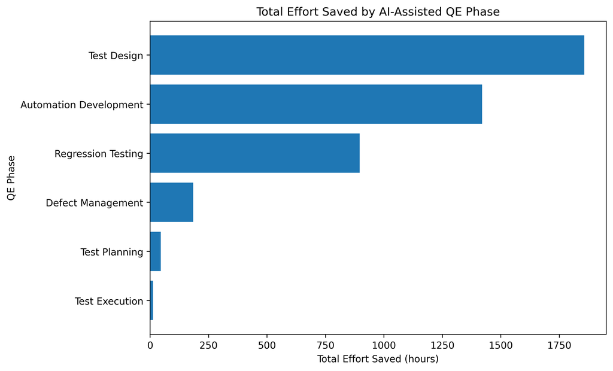

Figure 12 Actual vs Predicted Productivity

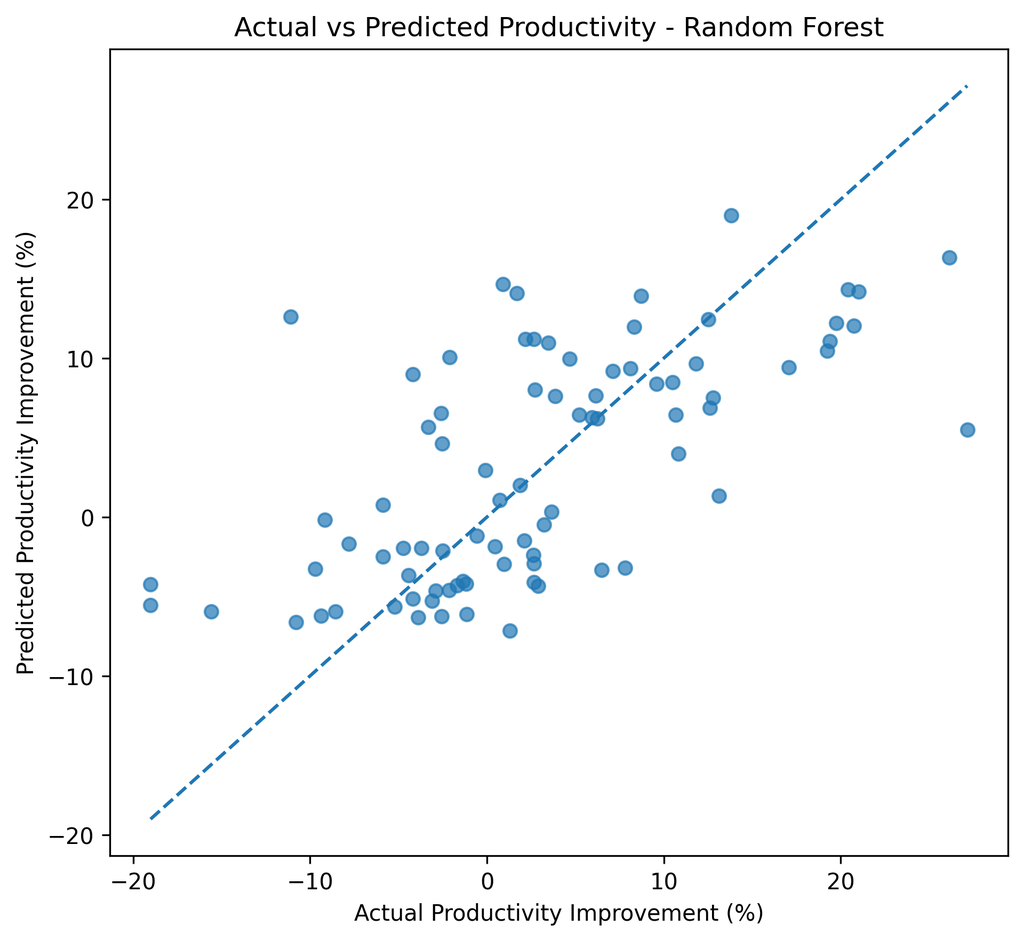

Figure 13 Permutation Feature Importance Stability

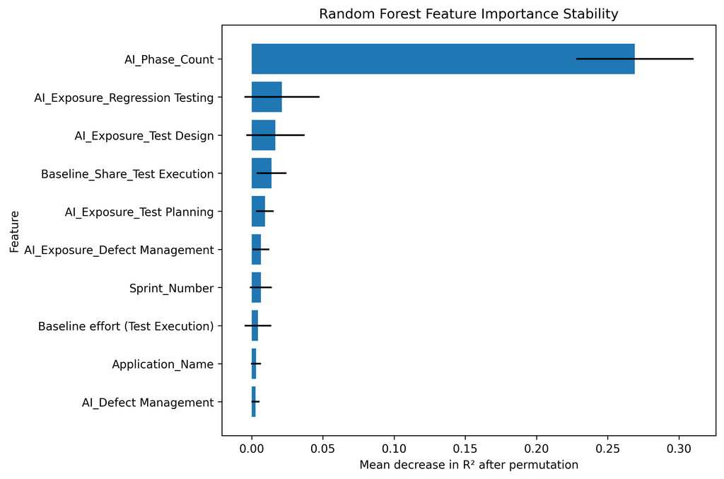

Figure 14 Repeated Grouped Holdout R2

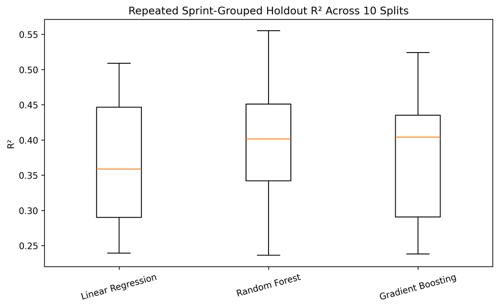

```python
for filename in [
    "Figure_11_Total_Effort_Saved_by_Phase.png",
    "Figure_12_Actual_vs_Predicted_Productivity.png",
    "Figure_13_Permutation_Feature_Importance_Stability.png",
    "Figure_14_Repeated_Grouped_Holdout_R2.png",
]:
    display(Markdown(f"### {filename.replace('_',' ').replace('.png','')}"))
    display(Image(filename=str(FIGURES/filename), width=850))
```

## 9. Reproducibility and Submission Notes

- Full final regeneration logic: `../scripts/final_analysis.py`
- Immutable source data: `../data/raw/EQEPD_Dataset_v5.xlsx`
- Processed datasets: `../data/processed/`
- Final evidence tables and figures: `../outputs/`
- Final report: `../reports/QM640_Final_Capstone_Report_Satish_Venugopal.docx` and `.pdf`
- Environment manifest: `../environment_versions.txt` and `../outputs/tables/Final_Execution_Environment.csv`

The analysis is observational and productivity-focused. It does not claim causal AI impact or complete financial ROI, and it does not use direct client, employee, source-code, production, or personally identifiable information.